# Stout Case Study #1

## Name: Shen Huang

## Email: huangs9@uci.edu

## Case Study #1

```python
import numpy as np
import pandas as pd
import matplotlib.pyplot as plt
import matplotlib as mpl
import seaborn as sns
from sklearn.model_selection import train_test_split
from sklearn import preprocessing
from sklearn.linear_model import LogisticRegression
from sklearn.tree import DecisionTreeClassifier
from sklearn import metrics
from sklearn.metrics import roc_curve, auc

plt.style.use('ggplot')
```

```python
df = pd.read_csv("D:/OA/Stout/PS_20174392719_1491204439457_log.csv")
```

## Exploratory Data Analysis

```python
df.info()
```

```
<class 'pandas.core.frame.DataFrame'>
RangeIndex: 6362620 entries, 0 to 6362619
Data columns (total 11 columns):
step              int64
type              object
amount            float64
nameOrig          object
oldbalanceOrg     float64
newbalanceOrig    float64
nameDest          object
oldbalanceDest    float64
newbalanceDest    float64
isFraud           int64
isFlaggedFraud    int64
dtypes: float64(5), int64(3), object(3)
memory usage: 534.0+ MB
```

The dataset has 11 columns and 6362620 rows. The following are the first 10 rows of the dataset.

```python
df.head(10)
```

|  | step | type | amount | nameOrig | oldbalanceOrg | newbalanceOrig | nameDest | oldbalanceDest | newbalanceDest | isFraud | isFlaggedFraud |
| --- | --- | --- | --- | --- | --- | --- | --- | --- | --- | --- | --- |
| 0 | 1 | PAYMENT | 9839.64 | C1231006815 | 170136.00 | 160296.36 | M1979787155 | 0.0 | 0.00 | 0 | 0 |
| 1 | 1 | PAYMENT | 1864.28 | C1666544295 | 21249.00 | 19384.72 | M2044282225 | 0.0 | 0.00 | 0 | 0 |
| 2 | 1 | TRANSFER | 181.00 | C1305486145 | 181.00 | 0.00 | C553264065 | 0.0 | 0.00 | 1 | 0 |
| 3 | 1 | CASH_OUT | 181.00 | C840083671 | 181.00 | 0.00 | C38997010 | 21182.0 | 0.00 | 1 | 0 |
| 4 | 1 | PAYMENT | 11668.14 | C2048537720 | 41554.00 | 29885.86 | M1230701703 | 0.0 | 0.00 | 0 | 0 |
| 5 | 1 | PAYMENT | 7817.71 | C90045638 | 53860.00 | 46042.29 | M573487274 | 0.0 | 0.00 | 0 | 0 |
| 6 | 1 | PAYMENT | 7107.77 | C154988899 | 183195.00 | 176087.23 | M408069119 | 0.0 | 0.00 | 0 | 0 |
| 7 | 1 | PAYMENT | 7861.64 | C1912850431 | 176087.23 | 168225.59 | M633326333 | 0.0 | 0.00 | 0 | 0 |
| 8 | 1 | PAYMENT | 4024.36 | C1265012928 | 2671.00 | 0.00 | M1176932104 | 0.0 | 0.00 | 0 | 0 |
| 9 | 1 | DEBIT | 5337.77 | C712410124 | 41720.00 | 36382.23 | C195600860 | 41898.0 | 40348.79 | 0 | 0 |

```python
pd.isnull(df).sum().sum()
```

```
0
```

The dataset has no missing values.

```python
df.describe()
```

|  | step | amount | oldbalanceOrg | newbalanceOrig | oldbalanceDest | newbalanceDest | isFraud | isFlaggedFraud |
| --- | --- | --- | --- | --- | --- | --- | --- | --- |
| count | 6.362620e+06 | 6.362620e+06 | 6.362620e+06 | 6.362620e+06 | 6.362620e+06 | 6.362620e+06 | 6.362620e+06 | 6.362620e+06 |
| mean | 2.433972e+02 | 1.798619e+05 | 8.338831e+05 | 8.551137e+05 | 1.100702e+06 | 1.224996e+06 | 1.290820e-03 | 2.514687e-06 |
| std | 1.423320e+02 | 6.038582e+05 | 2.888243e+06 | 2.924049e+06 | 3.399180e+06 | 3.674129e+06 | 3.590480e-02 | 1.585775e-03 |
| min | 1.000000e+00 | 0.000000e+00 | 0.000000e+00 | 0.000000e+00 | 0.000000e+00 | 0.000000e+00 | 0.000000e+00 | 0.000000e+00 |
| 25% | 1.560000e+02 | 1.338957e+04 | 0.000000e+00 | 0.000000e+00 | 0.000000e+00 | 0.000000e+00 | 0.000000e+00 | 0.000000e+00 |
| 50% | 2.390000e+02 | 7.487194e+04 | 1.420800e+04 | 0.000000e+00 | 1.327057e+05 | 2.146614e+05 | 0.000000e+00 | 0.000000e+00 |
| 75% | 3.350000e+02 | 2.087215e+05 | 1.073152e+05 | 1.442584e+05 | 9.430367e+05 | 1.111909e+06 | 0.000000e+00 | 0.000000e+00 |
| max | 7.430000e+02 | 9.244552e+07 | 5.958504e+07 | 4.958504e+07 | 3.560159e+08 | 3.561793e+08 | 1.000000e+00 | 1.000000e+00 |

```python
print('Number of true transaction:')
print(df['isFraud'].value_counts())
print('\n Flagged transaction:')
print(df['isFlaggedFraud'].value_counts())
```

```
Number of true transaction:
0    6354407
1       8213
Name: isFraud, dtype: int64

 Flagged transaction:
0    6362604
1         16
Name: isFlaggedFraud, dtype: int64
```

As we can see, the number of true fraudulent transaction is 8213 while the number of flagged fraudulent transaction is only 16, where the flags are seriously inconsistent with the facts.

```
Statistics of transaction type:
CASH_OUT    2237500
PAYMENT     2151495
CASH_IN     1399284
TRANSFER     532909
DEBIT         41432
Name: type, dtype: int64
```

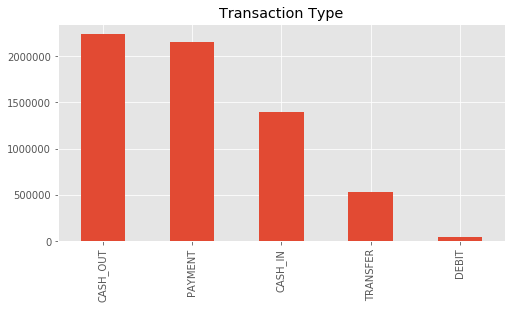

```python
print('Statistics of transaction type:')
print(df['type'].value_counts())
fig, ax = plt.subplots(1, 1, figsize=(8, 4))
df['type'].value_counts().plot(kind='bar', title='Transaction Type', ax=ax, figsize=(8, 4))
plt.show()
```

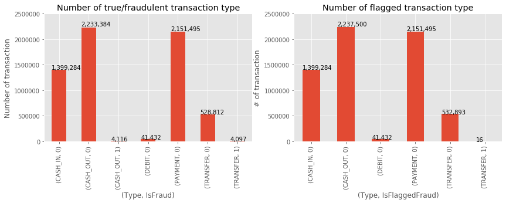

```python
plt.figure(figsize=(14,4))

plt.subplot(1,2,1)

ax = df.groupby(['type', 'isFraud']).size().plot(kind='bar')
ax.set_title('Number of true/fraudulent transaction type')
ax.set_xlabel('(Type, IsFraud)')
ax.set_ylabel('Number of transaction')
ax.set_ylim([0, 2500000])

for p in ax.patches:
    ax.annotate(str(format(int(p.get_height()), ',d')), (p.get_x(), p.get_height()*1.01))

plt.subplot(1,2,2)

ax = df.groupby(['type', 'isFlaggedFraud']).size().plot(kind='bar')
ax.set_title('Number of flagged transaction type')
ax.set_xlabel('(Type, IsFlaggedFraud)')
ax.set_ylabel('# of transaction')
ax.set_ylim([0, 2500000])

for p in ax.patches:
    ax.annotate(str(format(int(p.get_height()), ',d')), (p.get_x(), p.get_height()*1.01))


plt.show()
```

From the above bar charts, we can observe that the transaction of cash_in, debit and payment are all true, over 0.18% transaction of cash out and 0.76% transaction of transfer are fraudulent. The wrong flag mainly occurs in the judgment of the transfer transaction. Therefore, I will focus on the data of transfer transaction in the next step.

```python
transfer_data = df[df['type'] == 'TRANSFER']
```

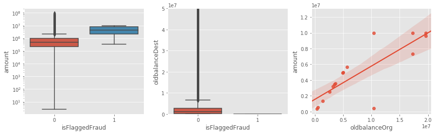

```python
fig, axs = plt.subplots(1,3, figsize=(15, 4)) #
a = sns.boxplot(x='isFlaggedFraud', y='amount', data=transfer_data, ax=axs[0])
axs[0].set_yscale('log')

b = sns.boxplot(x='isFlaggedFraud', y='oldbalanceDest', data=transfer_data, ax=axs[1])
axs[1].set(ylim=(0, 0.5e8))

c = sns.regplot(x='oldbalanceOrg', y='amount', data=transfer_data[transfer_data['isFlaggedFraud'] ==1], ax=axs[2])
plt.show()
```

Observing the relationship between the transfer amount and whether the it is flagged as fraud, we can see that transfer transactions marked as fraud tend to have higher amounts and those accounts have lower initial balance. The interesting note is that there may be a linear relationship between initial balance and transfer amount, the more the original balance of the account, the more it will be transferred out.

## Predictive modeling

Since the transactions of cash_in, debit and payment are all true, I will build two models, Logistic Regression and Decision Tree, to focus on the prediction of transactions of cash out and transfer.

To encode the transactions type, I set a new variable called typeCategory, typeCategory = 1 indicates transactio is transfer and typeCategory = 0 indicates transactio is cash out.

```python
df2 = df[(df['type'] == 'TRANSFER') | (df['type'] == 'CASH_OUT')]

type_label_encoder = preprocessing.LabelEncoder()
type_category = type_label_encoder.fit_transform(df2['type'].values)
df2['typeCategory'] = type_category
df2.drop(['step', 'nameOrig', 'nameDest', 'isFlaggedFraud','type'], axis=1, inplace=True)

df2.head(10)
```

|  | amount | oldbalanceOrg | newbalanceOrig | oldbalanceDest | newbalanceDest | isFraud | typeCategory |
| --- | --- | --- | --- | --- | --- | --- | --- |
| 2 | 181.00 | 181.00 | 0.0 | 0.0 | 0.00 | 1 | 1 |
| 3 | 181.00 | 181.00 | 0.0 | 21182.0 | 0.00 | 1 | 0 |
| 15 | 229133.94 | 15325.00 | 0.0 | 5083.0 | 51513.44 | 0 | 0 |
| 19 | 215310.30 | 705.00 | 0.0 | 22425.0 | 0.00 | 0 | 1 |
| 24 | 311685.89 | 10835.00 | 0.0 | 6267.0 | 2719172.89 | 0 | 1 |
| 42 | 110414.71 | 26845.41 | 0.0 | 288800.0 | 2415.16 | 0 | 0 |
| 47 | 56953.90 | 1942.02 | 0.0 | 70253.0 | 64106.18 | 0 | 0 |
| 48 | 5346.89 | 0.00 | 0.0 | 652637.0 | 6453430.91 | 0 | 0 |
| 51 | 23261.30 | 20411.53 | 0.0 | 25742.0 | 0.00 | 0 | 0 |
| 58 | 62610.80 | 79114.00 | 16503.2 | 517.0 | 8383.29 | 0 | 1 |

```python
X = df2[['amount', 'oldbalanceOrg', 'newbalanceOrig', 'oldbalanceDest', 'newbalanceDest', 'typeCategory']]
y = df2['isFraud']
```

```python
X_train, X_test, y_train, y_test = train_test_split(X, y, test_size=0.3, random_state=1)
```

### Logistic Regression

```python
clf = LogisticRegression()
clf.fit(X_train, y_train)
y_pred = clf.predict(X_test)
y_pred_score = clf.predict_proba(X_test)
```

```python
print(metrics.classification_report(y_test, y_pred))
```

```
              precision    recall  f1-score   support

           0       1.00      1.00      1.00    828642
           1       0.53      0.72      0.61      2481

    accuracy                           1.00    831123
   macro avg       0.77      0.86      0.80    831123
weighted avg       1.00      1.00      1.00    831123
```

[figure not shown]

```python
fpr, tpr, thresholds = roc_curve(y_test, y_pred_score[:, 1])
roc_auc = auc(fpr,tpr)
plt.title('Receiver Operating Characteristic (Decision Tree)')
plt.plot(fpr, tpr, 'b',label='AUC = %0.2f'% roc_auc)
plt.legend(loc='lower right')
plt.plot([0,1],[0,1],'r--')
plt.xlim([-0.1,1.0])
plt.ylim([-0.1,1.01])
plt.ylabel('True Positive Rate')
plt.xlabel('False Positive Rate')
plt.show()
```

### Decision Tree

```python
clf2 = DecisionTreeClassifier()
clf2 = clf2.fit(X_train,y_train)
y_pred2 = clf2.predict(X_test)
y_pred_score2 = clf2.predict_proba(X_test)
```

```python
print(metrics.classification_report(y_test, y_pred2))
```

```
              precision    recall  f1-score   support

           0       1.00      1.00      1.00    828642
           1       0.91      0.89      0.90      2481

    accuracy                           1.00    831123
   macro avg       0.95      0.94      0.95    831123
weighted avg       1.00      1.00      1.00    831123
```

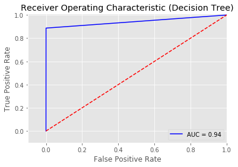

```python
fpr, tpr, thresholds = roc_curve(y_test, y_pred_score2[:, 1])
roc_auc = auc(fpr,tpr)
plt.title('Receiver Operating Characteristic (Decision Tree)')
plt.plot(fpr, tpr, 'b',label='AUC = %0.2f'% roc_auc)
plt.legend(loc='lower right')
plt.plot([0,1],[0,1],'r--')
plt.xlim([-0.1,1.0])
plt.ylim([-0.1,1.01])
plt.ylabel('True Positive Rate')
plt.xlabel('False Positive Rate')
plt.show()
```

The data is imbalanced, models will have a better performance if we can get more sample data.